# Reproducible Research: Peer Assessment 1

## Loading and preprocessing the data

This section describes the process to unzip dataset file and read it into a dataframe called “**`activity`**.” The first three lines of code which have been commented out shows the steps to download the dataset if unavailable in the project folder.

```r
# file.URL <- "https://d396qusza40orc.cloudfront.net/repdata%2Fdata%2Factivity.zip"
# file.dir <- "./activity.zip"
# download.file(file.URL, file.dir, method = "auto")


file.name <- "activity.csv"
file.dir <- "./activity.zip"
unzip(file.dir)
activity <- read.csv(file.name, na.strings = "NA")
file.remove(file.name)
rm(file.dir, file.name)
```

Next, we will check the data and perform any pre-processing as required.

```r
# check dataframe
str(activity)
```

```
## 'data.frame':    17568 obs. of  3 variables:
##  $ steps   : int  NA NA NA NA NA NA NA NA NA NA ...
##  $ date    : chr  "2012-10-01" "2012-10-01" "2012-10-01" "2012-10-01" ...
##  $ interval: int  0 5 10 15 20 25 30 35 40 45 ...
```

```r
# check for missing values
colSums(is.na(activity))
```

```
##    steps     date interval
##     2304        0        0
```

```r
# convert date from character to date format
activity$date <- as.Date(activity$date, format = "%Y-%m-%d")
head(activity)
```

```
##   steps       date interval
## 1    NA 2012-10-01        0
## 2    NA 2012-10-01        5
## 3    NA 2012-10-01       10
## 4    NA 2012-10-01       15
## 5    NA 2012-10-01       20
## 6    NA 2012-10-01       25
```

```r
str(activity)
```

```
## 'data.frame':    17568 obs. of  3 variables:
##  $ steps   : int  NA NA NA NA NA NA NA NA NA NA ...
##  $ date    : Date, format: "2012-10-01" "2012-10-01" ...
##  $ interval: int  0 5 10 15 20 25 30 35 40 45 ...
```

## What is mean total number of steps taken per day?

To find this, we will first create a vector for total daily steps by summing steps for a given date using the tapply function. As there are missing values, we will just ignore them for this question. Using this vector, we will calculate the daily mean, median and plot a histogram of total daily steps.

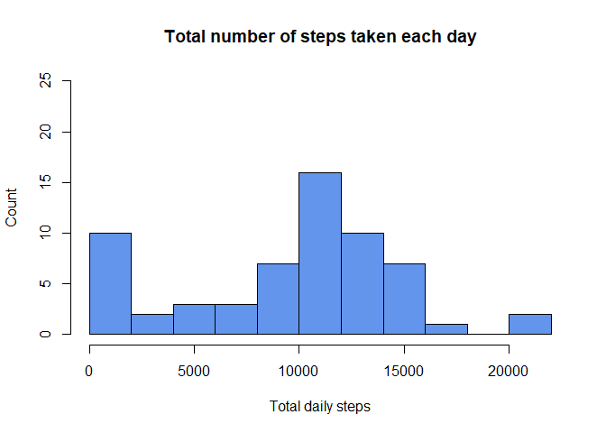

```r
# Total number of steps taken per day, mean and median
total.daily.steps <-
        with(activity, tapply(steps, date, sum, na.rm = TRUE))
mean.daily.steps <- mean(total.daily.steps)
median.daily.steps <- median(total.daily.steps)


# histogram of the total number of steps taken each day
hist(
        x = total.daily.steps,
        breaks = 8,
        col = "cornflowerblue",
        main = "Total number of steps taken each day",
        xlab = "Total daily steps",
        ylab = "Count",
        ylim = c(0, 25)
)
```

The average number of steps taken in a day is 9,354 and the median is 10,395.

## What is the average daily activity pattern?

For this question, we will first create a data frame by grouping observations in the same interval over the 61 days.

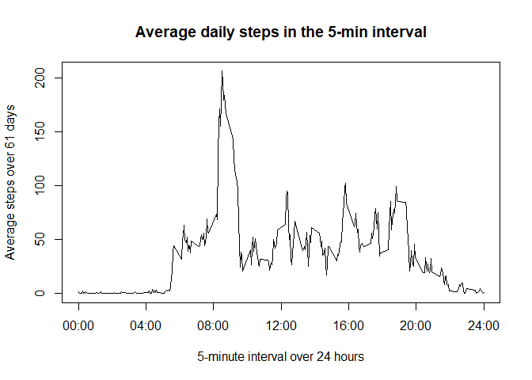

```r
# Make a time series plot (i.e. type = "l") of the 5-minute interval (x-axis)
# and the average number of steps taken, averaged across all days (y-axis)

daily.steps <- activity %>%
        group_by(interval) %>%
        summarise("Average.Daily.Steps" = mean(steps, na.rm = TRUE))

interval.breaks <- c(0, 392.5, 785, 1177.5, 1570, 1962.5, 2355)
interval.labels <- c("00:00", "04:00", "08:00",
                     "12:00", "16:00", "20:00", "24:00")
with(
        daily.steps,
        plot(
                x = interval,
                y = Average.Daily.Steps,
                type = "l",
                main = "Average daily steps in the 5-min interval",
                xlab = "5-minute interval over 24 hours",
                ylab = "Average steps over 61 days",
                xaxt = "n"
        )
)
axis(1, at = interval.breaks, labels = interval.labels)
```

The next part of this questions is to find the 5-min interval which contains the maximum number of steps. To find that, we will use the `which.max()` function on the above data frame.

```r
# Which 5-minute interval, on average across all the days in the dataset,
# contains the maximum number of steps?
max.step.index <- which.max(daily.steps$Average.Daily.Steps)
time_start <- sprintf("%02d:%02d", ((max.step.index * 5) %/% 60),
                      ((max.step.index * 5) %% 60))
time_end <- sprintf("%02d:%02d", ((max.step.index * 5 + 5) %/% 60),
                    ((max.step.index * 5 + 5) %% 60))
max.steps <- daily.steps$Average.Daily.Steps[max.step.index]
# cat(paste0("From ", time_start, " - ", time_end, "AM with ",
#         format(max.steps, digits = 3), " steps."))
```

The maximum number of steps taken during the day over the 61 days is from 08:40 to 08:45 (AM).

## Imputing missing values

```r
# Calculate and report the total number of missing values in the dataset (i.e. the total number of rows with NAs)
missing.obs <- length(activity[rowSums(is.na(activity)) > 0, 1])
colSums(is.na(activity))
```

```
##    steps     date interval
##     2304        0        0
```

```r
round(missing.obs / nrow(activity) * 100, 2)
```

```
## [1] 13.11
```

```r
# Devise a strategy for filling in all of the missing values in the dataset. The strategy does not need to be sophisticated. For example, you could use the mean/median for that day, or the mean for that 5-minute interval, etc.

# Create a new dataset that is equal to the original dataset but with the missing data filled in.

missing.index <- which(rowSums(is.na(activity)) > 0)
length(missing.index)
```

```
## [1] 2304
```

```r
# checking if steps is missing for all intervals or entire day
activity$interval[missing.index]
```

[output not shown]

[output cut: 150 more lines]

```r
# see count of missing values by date
table(activity$date[missing.index])
```

```
##
## 2012-10-01 2012-10-08 2012-11-01 2012-11-04 2012-11-09 2012-11-10 2012-11-14
##        288        288        288        288        288        288        288
## 2012-11-30
##        288
```

```r
## 8 days with missing data for full day
## 8 * 288 = 2,304 === total missing values
```

Note that the missing data is for eight days. On these days, data is missing for the whole day. Thus, instead of filling in these data with the daily average, we will fill in each 5-min interval with the average for the interval over 61 days.

```r
# create a copy of data frame
activity2 <- activity

# replace missing values with average number of steps in the 5-min interval
# average daily steps for 5-min interval (288 values) repeated 8 times
# for 8 missing days == 2,304
activity2$steps[missing.index] <-
        rep(daily.steps$Average.Daily.Steps, 8)
activity2$steps <- as.integer(activity2$steps)

# checking for NAs after imputation
colSums(is.na(activity2))
```

```
##    steps     date interval
##        0        0        0
```

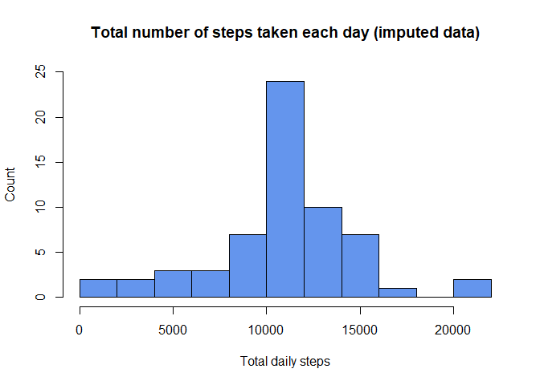

```r
# Make a histogram of the total number of steps taken each day and Calculate and report the mean and median total number of steps taken per day. Do these values differ from the estimates from the first part of the assignment? What is the impact of imputing missing data on the estimates of the total daily number of steps?

total.daily.steps2 <-
        with(activity2, tapply(steps, date, sum))
mean.daily.steps2 <- mean(total.daily.steps2)
median.daily.steps2 <- median(total.daily.steps2)


# histogram of the total number of steps taken each day
hist(
        x = total.daily.steps2,
        breaks = 8,
        col = "cornflowerblue",
        main = "Total number of steps taken each day (imputed data)",
        xlab = "Total daily steps",
        ylab = "Count",
        ylim = c(0, 25)
)
```

Notice that the graph looks quite different from the one with missing value. To get a full appreciation of these two graphs and datasets, the original and the imputed, we can use a panel plot from the `lattice` package to view them simultaneously.

```r
# comparison via panel plot
library(lattice)
df <-
        data.frame(
                "Steps" = c(total.daily.steps, total.daily.steps2),
                "Group" = c(rep("Raw data", 61), rep("Imputed data", 61))
        )
head(df)
```

```
##   Steps    Group
## 1     0 Raw data
## 2   126 Raw data
## 3 11352 Raw data
## 4 12116 Raw data
## 5 13294 Raw data
## 6 15420 Raw data
```

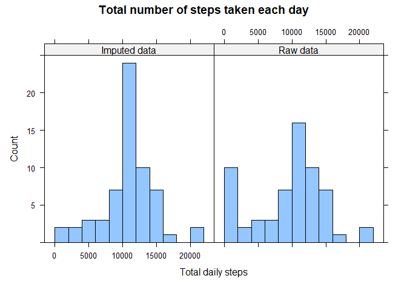

```r
histogram(
        ~ Steps | Group,
        data = df,
        type = "count",
        breaks = 11,
        main = "Total number of steps taken each day",
        xlab = "Total daily steps",
        ylab = "Count",
        ylim = c(0, 25)
)
```

## Are there differences in activity patterns between weekdays and weekends?

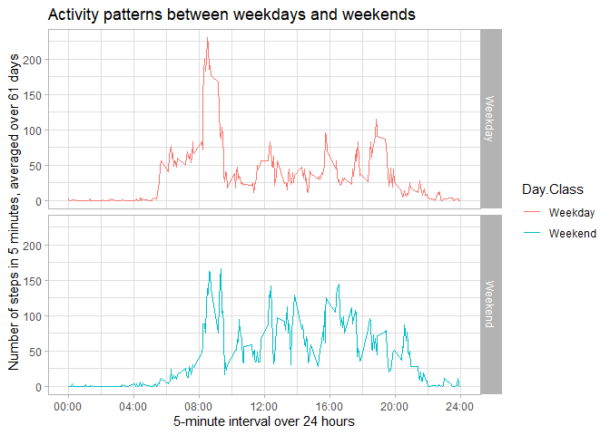

```r
# For this part the weekdays() function may be of some help here. Use the dataset with the filled-in missing values for this part.

# Create a new factor variable in the dataset with two levels – “weekday” and “weekend” indicating whether a given date is a weekday or weekend day.
activity2$Day.Class <-
        ifelse((weekdays(activity2$date, TRUE) %in% c("Sat", "Sun")),
               yes = "Weekend", no = "Weekday")


# Make a panel plot containing a time series plot (i.e. type = "l") of the 5-minute interval (x-axis) and the average number of steps taken, averaged across all weekday days or weekend days (y-axis). See the README file in the GitHub repository to see an example of what this plot should look like using simulated data.
average.by.day.of.week <- activity2 %>%
        group_by(Day.Class, interval) %>%
        summarise(Avg = mean(steps))

average.by.day.of.week %>%
        ggplot(aes(x = interval, y = Avg, group = Day.Class)) +
        geom_line(aes(color = Day.Class)) +
        facet_grid(rows = vars(Day.Class)) +
        theme_light() +
        labs(
                title = "Activity patterns between weekdays and weekends",
                x = "5-minute interval over 24 hours",
                y = "Number of steps in 5 minutes, averaged over 61 days",
                group = "Day Type"
        ) +
        scale_x_continuous(breaks = interval.breaks, labels = interval.labels)
```